# The Carpentries Instructor Training Assessment Report

Authors: Kelly Barnes, Erin Becker, and Karen Word

Last edited: August 26, 2021

# 1 Executive Summary and Key Findings

- **The Carpentries’ [Instructor Training Program](https://docs.carpentries.org/topic_folders/instructor_training/index.html):**
  - trains people to teach The Carpentries curricula through an active training that includes fundamentals of cognitive psychology, mechanics of a positive learning environment, and content specific to The Carpentries community.
- **The purposes of this report are to:**
  - provide an update on the successes, challenges, and growth of the Instructor Training program to the Executive Council, Trainers Leadership, Trainers, and broader Carpentries community; and
  - help the Instructor training team, Core Team, Executive Council, and Trainers Leadership identify trends and opportunities that can drive continuous program improvement.
- **This report relies on two primary sources of data:**
  - pre and post Instructor Training Surveys, and
  - programmatic data from The Carpentries AMY database.

**Instructor Training Outcomes**

**Trainee Demographics**

- Trainees provide demographic information before attending Instructor Training which helps us better understand who we are teaching.
- A majority of trainees (62%) are located in the United States, followed by the United Kingdom, Canada, and Australia. Other countries in the top ten include European countries as well as South Africa and Argentina.
- The highest percentage of trainees come from the fields of Computer Science (19%), Bioinformatics/Genomics (16%), and Library Science (12%) which likely speaks to the origins of the Software, Data Carpentry, and Library Carpentry communities.
- The highest percentage of our trainees are graduate students (26%) followed closely by research staff (24%). We also have a sizeable portion of faculty (16%) and postdoctoral researchers (13%). We have smaller numbers of trainees that come from government and industry.
- Because of regulations, we only collect ethnic identity information from US-based trainees. Among US trainees from 2018 to 2020, the greatest number of trainees identify as White (66%), followed by Asian (17%) and Hispanic/Latino(a) (8%).

**Outcomes Related to The Carpentries Community**

- While one goal of The Carpentries Instructor Training Program is to develop the individual Instructor, another goal is to build The Carpentries community. The following findings are associated with the Carpentries community.
- After attending an Instructor Training event, trainees can choose to complete three checkout exercises: 1) attending a community discussion, 2) completing a teaching demonstration, and 3) contributing to a Carpentries lesson. After these steps, trainees are awarded a badge and are considered certified Carpentries Instructors, qualified to teach any Software, Data, or Library Carpentry workshops.
- Over the past three years (2017 - 2020), the total number of trainees who become certified Instructors has increased from 464 to 625 annually.
- The percentage of trainees who complete certification is generally between 50-60%. This number declined slightly, from 57% to 54% between 2017 and 2019, rising to 55% in 2020.
- In 2019 and 2020, 28% of trainees who attended Instructor Training never began checkout, while 15% completed some but not all steps. Of those steps, trainees participated in a community discussion most often. Far fewer trainees completed a teaching demonstration or shared a lesson contribution.
- After certification, Instructors typically teach their first workshop within six months.

**Growth of Instructor Training Efforts**

- The Carpentries received [a grant from the Chan Zuckerberg Initiative](https://carpentries.org/blog/2019/11/czi-moore-grant/) to support growth in our Instructor and Trainer Training Efforts between 2019 and 2022. This section reports on metrics related to that growth.
- In 2019, we certified 10 new Instructor Trainers (“Trainers”) to teach Instructor Training and host teaching demonstrations. In 2020, we trained two cohorts of new Trainers and certified our highest number of Trainers in one year to date, 29. In July 2021, we certified an additional 14 new Trainers.
- In 2019, 1,168 trainees attended Instructor Training. In 2020, the number of trainees declined to 895. As of August, we have trained 717 in 2021.

**Conclusion**

- Trainees rate their Instructor Training experience as highly positive. They find the training welcoming, learn valuable skills, and leave with increased motivation to learn.
- Areas of potential growth include adding support to ensure that trainees who begin the checkout process have the support they need to complete it, and leveraging the growth in our Instructor Trainer community to expand our training audience. These and other goals must address continuing global unpredictability, supporting the ambitions of our community-members amid the strain of changing workplace and family landscapes.
- The success of The Carpentries Instructor Training program hinges on the strength of our outstanding Trainer community. Trainers create welcoming and inclusive spaces for our trainees to learn. They are knowledgeable, enthusiastic, and kind. Our Trainers contribute thousands of hours to maintaining our curriculum, teaching Instructor Training, hosting teaching demonstrations, and continuing to improve their own teaching skills.

# 2 Introduction

## 2.1 Carpentries Instructor Training Program

[Carpentries workshops](https://carpentries.org/workshops/) teach researchers the skills and perspectives to work more effectively and reproducibly with data and software. Our workshops use open, collaboratively-developed [Data Carpentry](https://datacarpentry.org/lessons/), [Library Carpentry](https://librarycarpentry.org/lessons/), and [Software Carpentry](https://software-carpentry.org/lessons/) lessons with materials on topics from data organisation to version control and are taught by volunteer Instructors trained through our Instructor Training program.

The Carpentries’ [Instructor Training Program](https://docs.carpentries.org/topic_folders/instructor_training/index.html) is firmly grounded in educational research. We train people how to teach The Carpentries curricula through an active training that includes fundamentals of cognitive psychology, mechanics of a positive learning environment, and content specific to The Carpentries. Instructor Training is typically a two full-day or four half-day experience. As with our other lessons, our Instructor Training [curriculum](https://carpentries.github.io/instructor-training/) is open, collaboratively developed, and regularly updated.

The Carpentries Instructor Training has the following goals:

- Introduce trainees to evidence-based best practices of teaching.
- Teach how to create a positive environment for learners at The Carpentries workshops.
- Provide opportunities for trainees to practice and build their teaching skills.
- Help trainees become integrated into The Carpentries community.
- Prepare trainees to use these teaching skills in teaching The Carpentries workshops.

When people learn about Instructor Training, they sometimes anticipate that we will teach content that is not included. Examples of things we do **not** teach are:

- How to program in R or Python, use git or any other topics taught in Carpentries workshops.
- How to create lessons from scratch (although some principles we teach do apply).

After attending an Instructor Training event, trainees can choose to complete three checkout exercises: 1. Attending a community discussion. The purpose of this step is to introduce trainees to The Carpentries global community as a resource that they can use in the future when they prepare to teach and reflect on a workshop. 2. Completing a teaching demonstration. The purpose of this step is to support trainees in preparing to teach a full workshop and to provide an opportunity to give and receive feedback on a prepared lesson. This also includes feedback from a Carpentries Instructor Trainer and serves as a checkpoint where trainees may be invited to repeat a demonstration in order to ensure that they are fully prepared to implement Carpentries teaching practices. 3. Contributing to a Carpentries lesson or repository. The purpose of this step is to ensure that trainees are prepared to contribute to collaborative maintenance of the lessons they choose to teach in the future. After these steps, trainees are awarded a Carpentries Instructor badge and are considered certified Carpentries Instructors, qualified to teach any Carpentries workshops.

The Carpentries website has more details about how to [become an Instructor](https://carpentries.org/become-instructor/) and join The Carpentries community or become an [Organisational Member](https://carpentries.org/membership/) to grow a local community of Instructors within your organisation.

## 2.2 Purposes of this Report

The purposes of this report are to:

- provide an update on the growth, successes, and challenges of the Instructor Training program to the Executive Council, Trainers Leadership Group, Trainers, and broader Carpentries community.
- help the Instructor training team, Core Team, Executive Council, and Trainers Leadership Group identify trends and opportunities that can drive continuous program improvement.

# 3 Methods

The Instructor Training program’s assessment efforts focus on two primary sources of data:

## 3.1 Pre and Post Instructor Training Surveys

For the Instructor Training outcomes section of this report, we analyse trainees’ perceptions of the Instructor Training and their Instructor Trainers. We also look at how their perception of their skills and knowledge changes from before to after the training.

## 3.2 AMY Database

For the Community Outcomes Section of the report, we analyse current and historical programmatic Instructor Training information. The Carpentries began systematically recording data from workshops in 2012. These data are stored in our AMY database. Included are the number of and geographic reach of Instructor Training events, the number of trainees and their certification rates, and details on the training of new Instructor Trainers.

# 4 Instructor Training Outcomes

As mentioned previously, the stated goals of The Carpentries Instructor Training program are to:

- Introduce trainees to evidence-based best practices of teaching.
- Teach how to create a positive environment for learners at The Carpentries workshops.
- Provide opportunities for trainees to practice and build their teaching skills.
- Help trainees become integrated into The Carpentries community.
- Prepare trainees to use these teaching skills in teaching The Carpentries workshops.

To determine whether our Instructor Training program is meeting these goals, we ask all trainees to complete a survey about their skills and experience with Instructor Training curriculum content both before and after the training. We also ask demographic questions as well as their perceptions of the training and their Instructor Trainers. Finally, we ask how likely they are to recommend this Instructor Training to a friend or colleague.

## 4.1 What Skills Did Trainees Learn? Changes in Perceived Skills Before and After an Instructor Training.

First, let’s look at if trainees believe their skills changed from before to after the Instructor Training.

We asked trainees to describe their ability to do the following tasks using a five-point Likert scale ranging from “Extremely able” to “Not at all able”:

- Teach using live coding
- Create a Carpentries workshop website
- Use a concept map for lesson planning
- Write a multiple choice question with diagnostic power
- Write effective learning objectives

Note that the number of responses only reflects those who completed both pre-and post-surveys for graphs comparing Before and After Instructor Training.

### 4.1.1 Ability to Teach using Live Coding

Before Instructor Training, a substantial number of trainees fit into each ability level, with the highest number reporting being *moderately able* to teach using live coding. After Instructor Training, there was a shift. Fewer trainees reported being *neutral*, *slightly able*, or *not at all able*, and more trainees reported being *extremely able* or *moderately able*.

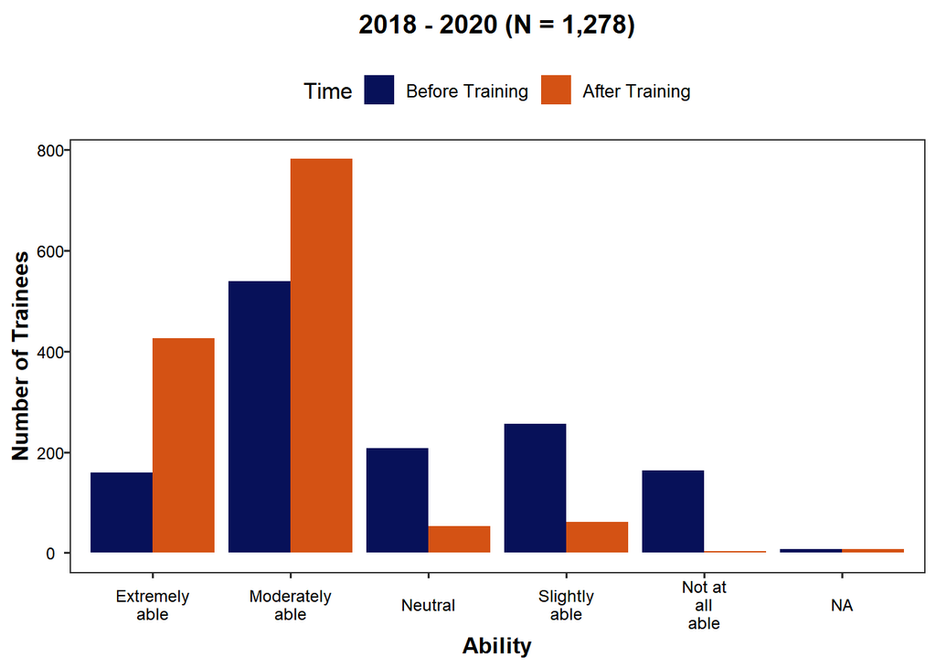

Figure 4.1: Ability to Teach Using Live Coding

### 4.1.2 Ability to Create a Carpentries Workshop Website

Before Instructor Training, the highest number of trainees report that they are *not at all able* to create a Carpentries workshop website. After Instructor Training, the highest number of trainees say that they are *moderately able*.

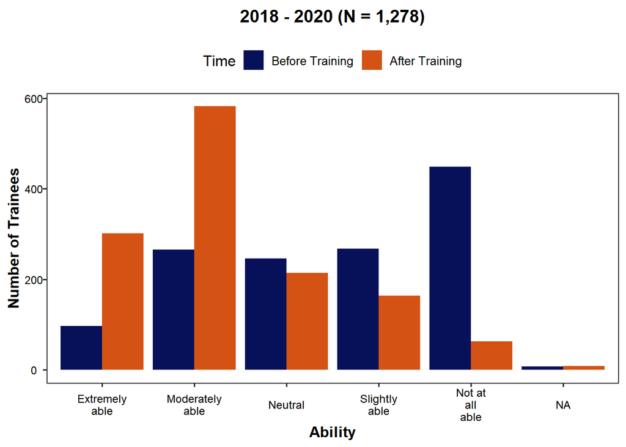

Figure 4.2: Ability to Create a Carpentries Workshop Website

### 4.1.3 Ability to Use a Concept Map for Lesson Planning

Before Instructor Training, the highest number of trainees reported being *not at all able* to use a concept map for lesson planning. After Instructor Training, the highest number of trainees reported being *moderately able*.

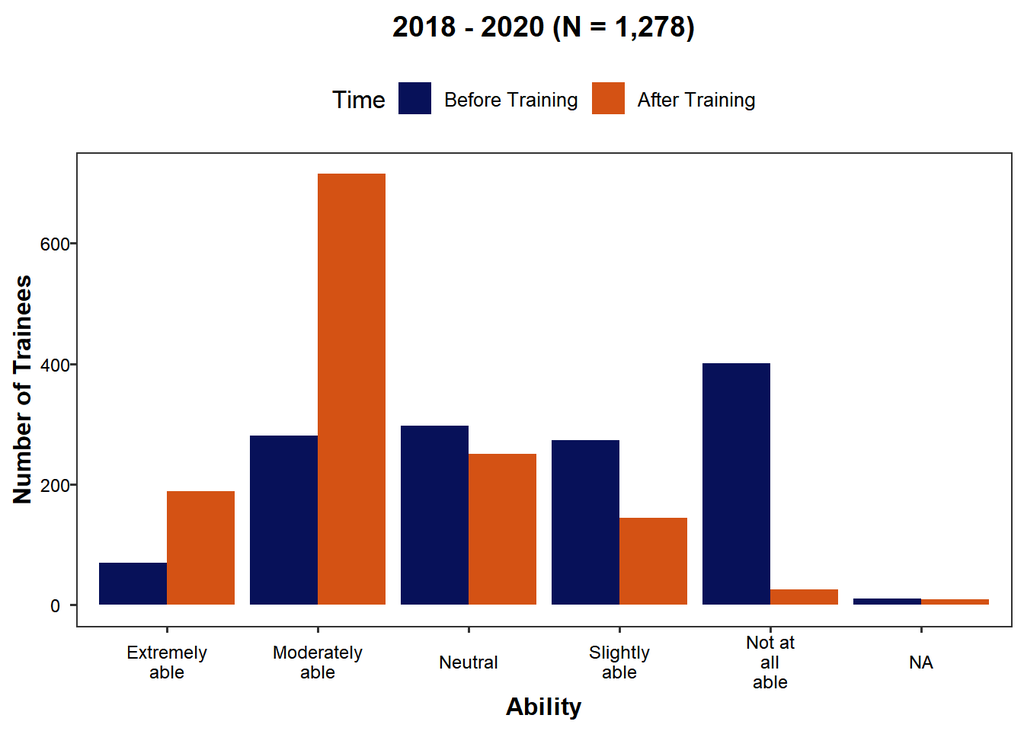

Figure 4.3: Ability to Use a Concept Map for Lesson Planning

### 4.1.4 Ability to Write Multiple Choice Questions with Diagnostic Power

Before Instructor Training, trainees were almost evenly split from *moderately able* to *not at all able* to write a multiple choice question with diagnostic power. After Instructor Training, trainees overwhelming reported being *moderately able*.

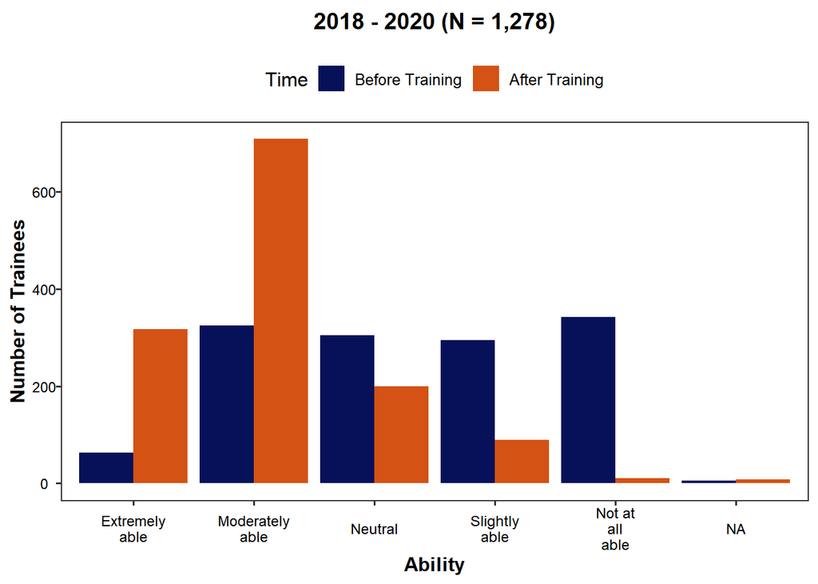

Figure 4.4: Ability to Write Multiple Choice Questions with Diagnostic Power

### 4.1.5 Ability to Write Effective Learning Objectives

Before Instructor Training, trainees were divided on their ability to write effective learning objectives. However, after Instructor Training, there is an apparent increase in the number of trainees reporting being *moderately able* or *extremely able* to write effective learning objectives.

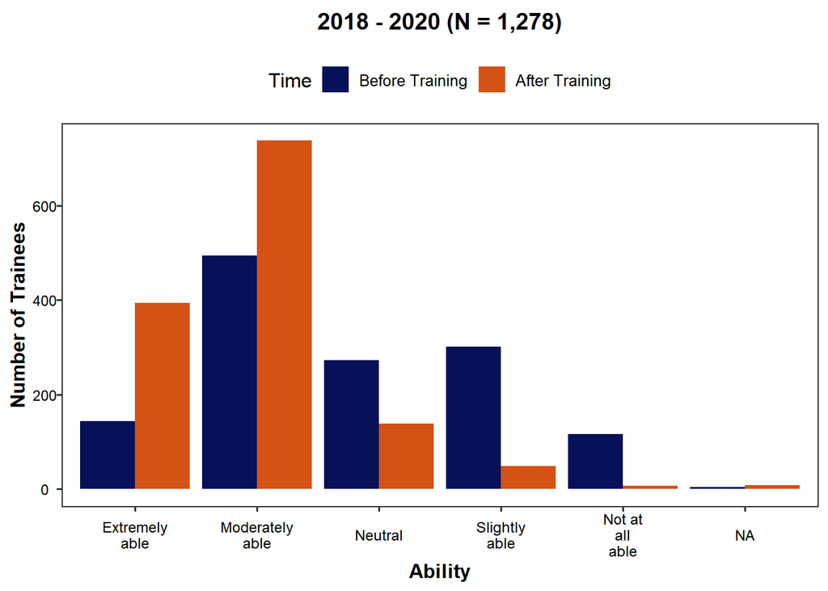

Figure 4.5: Ability to Write Effective Learning Objectives

## 4.2 What Knowledge Did Trainees Acquire? Changes in Perceived Knowledge Before and After an Instructor Training.

Next, we will examine whether trainees believe their knowledge changed from before to after the Instructor Training.

Trainees rated their knowledge about the following topics on a three-point scale from “Extensive knowledge of the topic” to “Little or no knowledge of the topic”:

- Formative vs. summative assessment
- Giving effective feedback
- What makes someone a novice or expert
- How human memory works
- Cognitive load
- What The Carpentries is and what it does
- Strategies to motivate learners

### 4.2.1 Knowledge of Formative vs. Summative Assessment

Before Instructor Training, trainees primarily reported that they had *little to no knowledge* of formative vs. summative assessment. However, following the training, the highest number of trainees reported having *some knowledge* of formative vs. summative assessment.

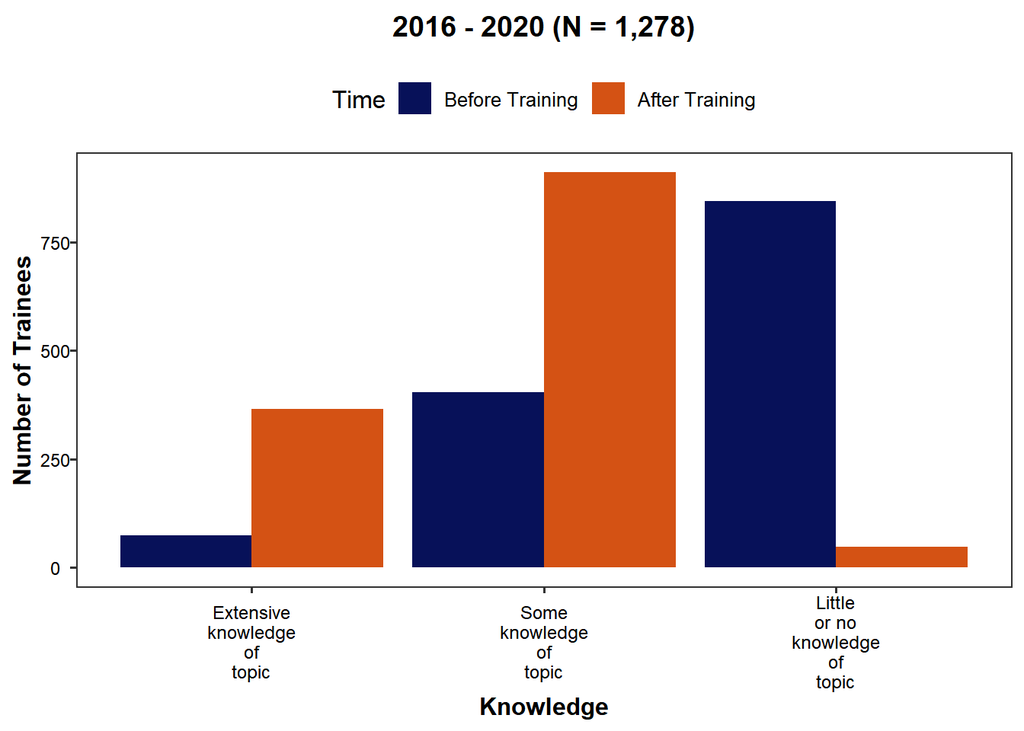

Figure 4.6: Knowledge about Formative vs. Summative Assessment

### 4.2.2 Knowledge of How to Give Effective Feedback

Before Instructor Training, trainees were most likely to report that they had *some knowledge* of how to give effective feedback. After Instructor Training, the number of trainees reporting *extensive knowledge* increased while the number reporting *little to no knowledge* dropped to almost zero.

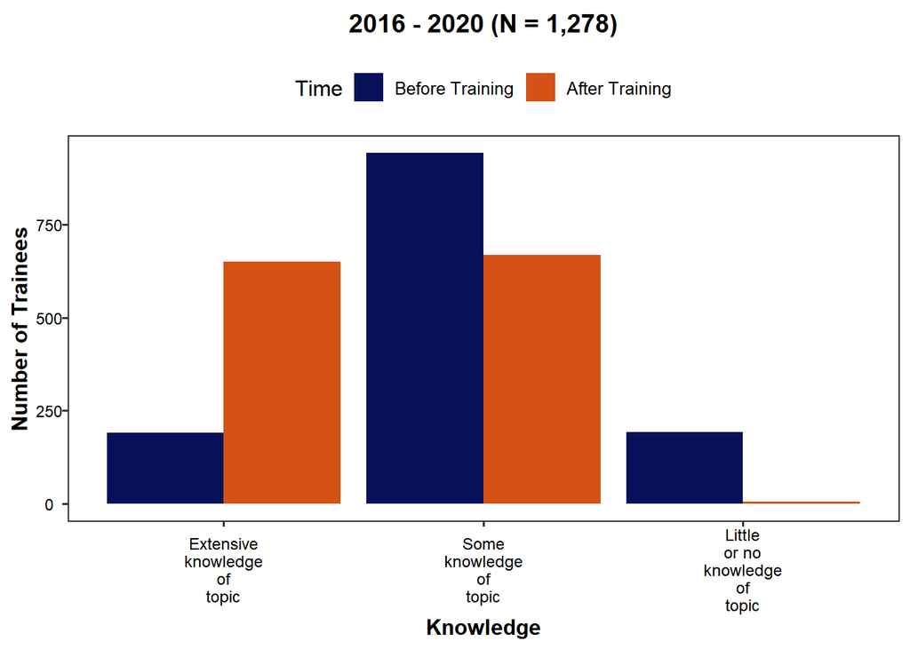

Figure 4.7: Knowledge of Giving Effective Feedback

### 4.2.3 Knowledge of What Makes Someone a Novice or Expert

Before Instructor Training, trainees were most likely to report that they had *some knowledge* of what makes someone a novice or expert. After Instructor Training, the number of trainees reporting *extensive knowledge* increased substantially while the number reporting *little to no knowledge* dropped to almost zero.

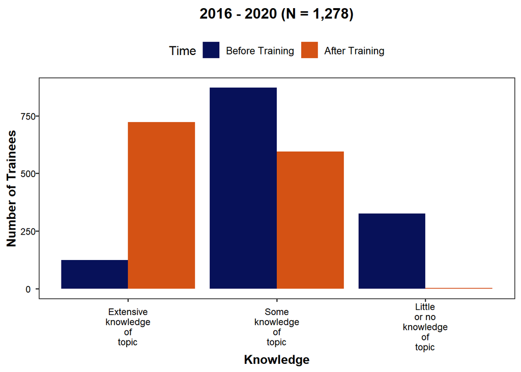

Figure 4.8: Knowledge of What Makes Someone a Novice or Expert

### 4.2.4 Knowledge of How Human Memory Works

Before Instructor Training, trainees were most likely to report that they had *some knowledge* of how human memory works. After Instructor Training, trainees reporting *extensive knowledge* increased while the number reporting *little to no knowledge* decreased substantially.

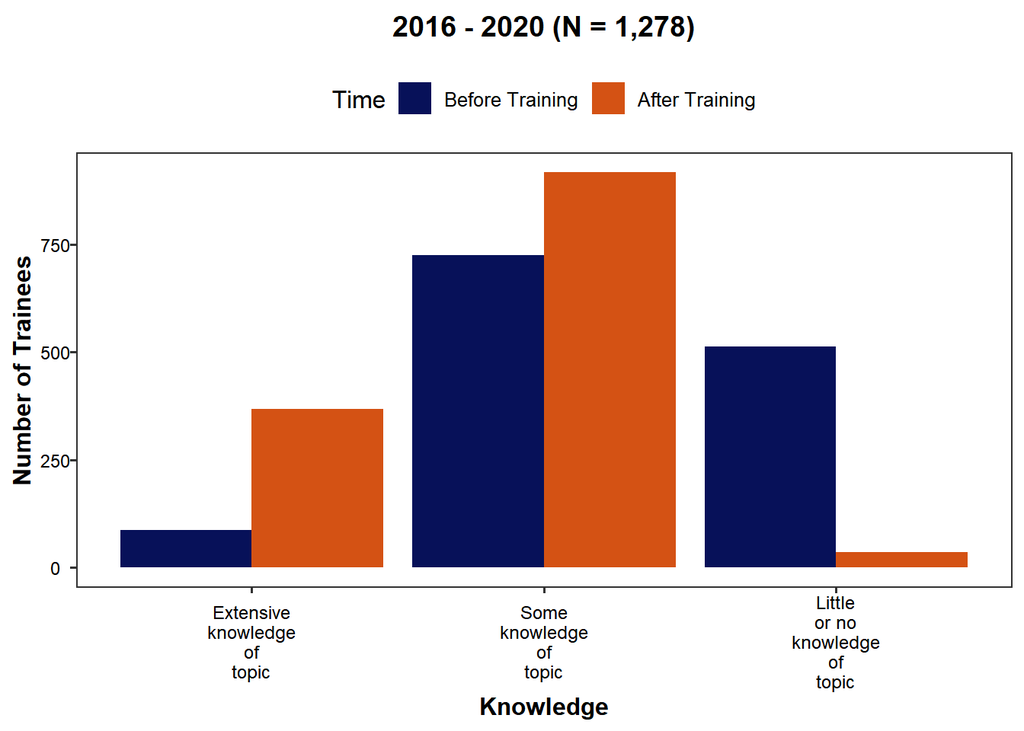

Figure 4.9: Knowledge of How Human Memory Works

### 4.2.5 Knowledge of Cognitive Load

Before Instructor Training, most trainees were split between reporting *some knowledge* or *little to no knowledge* of cognitive load. After Instructor Training, there was an increase in trainees reporting both *extensive knowledge* and *some knowledge*.

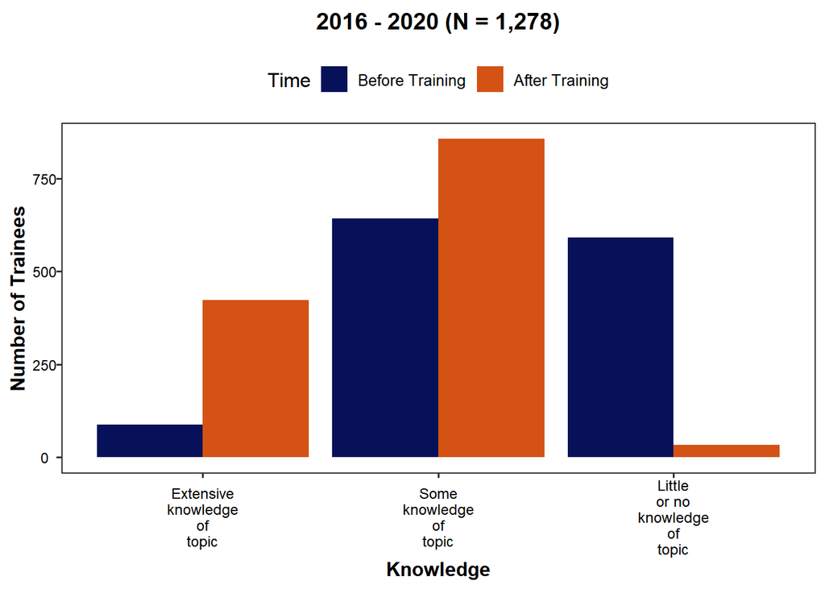

Figure 4.10: Knowledge of Cognitive Load

### 4.2.6 Knowledge of What The Carpentries is and What it Does

Before Instructor Training, many trainees reported having *some knowledge* of what The Carpentries is and what it does. After Instructor Training, trainees reporting *some knowledge* and *little to no knowledge* decreased while trainees reporting *extensive knowledge* increased substantially.

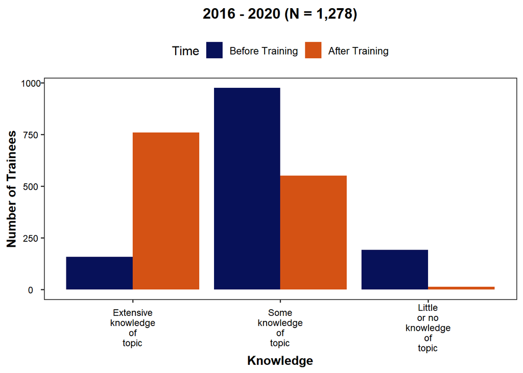

Figure 4.11: Knowledge of What The Carpentries is and What it Does

### 4.2.7 Knowledge of Strategies to Motivate Learners

Before Instructor Training, the highest number of trainees reported having *some knowledge* of strategies to motivate learners. After Instructor Training, those reporting *some knowledge* remained consistent while those with *little or no knowledge* dropped, and those reporting *extensive knowledge* increased substantially.

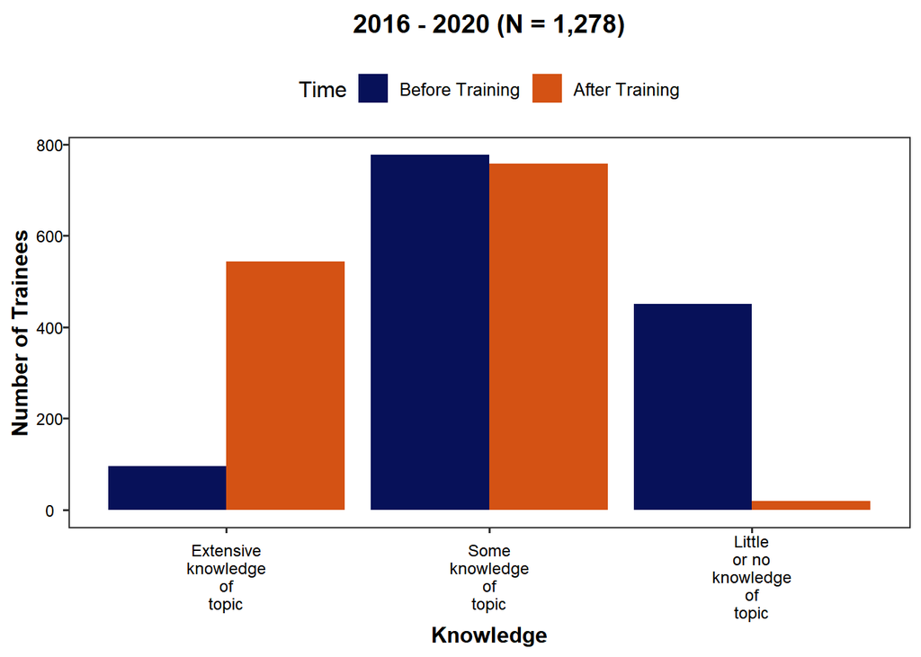

Figure 4.12: Knowledge of Strategies to Motivate Learners

## 4.3 Summary of Skills and Knowledge

We ask trainees to report on the perceptions of their skills and knowledge before and after Instructor Training in twelve teaching-related areas covered during the training.

Trainees report higher levels of ability or knowledge after Instructor Training for every skill and knowledge type. These results demonstrate that our Instructor Training program effectively meets its goals of introducing trainees to evidence-based teaching practices and providing skills they can use to improve their teaching.

While there is an increase in ability or knowledge across all areas, there is some variability. For example, we see a greater increase in trainees’ ability to teach using live coding (something we cover and practice in Instructor Training) than their ability to create a Carpentries workshop website (an exercise that many Trainers tend to skip). Similarly, we see a less clear increase in trainees’ ability to use a concept map for lesson planning. While this is an activity we cover extensively in Instructor Training, we consistently hear that some trainees struggle with this topic. These reflections suggest that perhaps there are opportunities in our curriculum to strengthen how we teach building workshop websites and concept maps.

## 4.4 Did Trainees Report a Change in Their Motivation to Learn After Instructor Training?

After Instructor Training, we asked trainees to describe how their motivation to learn about the following topics has changed:

- Formative vs. summative assessment
- Giving effective feedback
- What makes someone a novice or expert
- How human memory works
- Cognitive load
- What The Carpentries is and what it does
- Strategies to motivate learners

The majority of trainees reported increased motivation to continue learning across all seven topic areas. Percentages of trainees reporting increased motivation range from 63% for “What makes someone a novice or an expert” to 87% for “Strategies to motivate learners,” an average of 75% across topic areas.

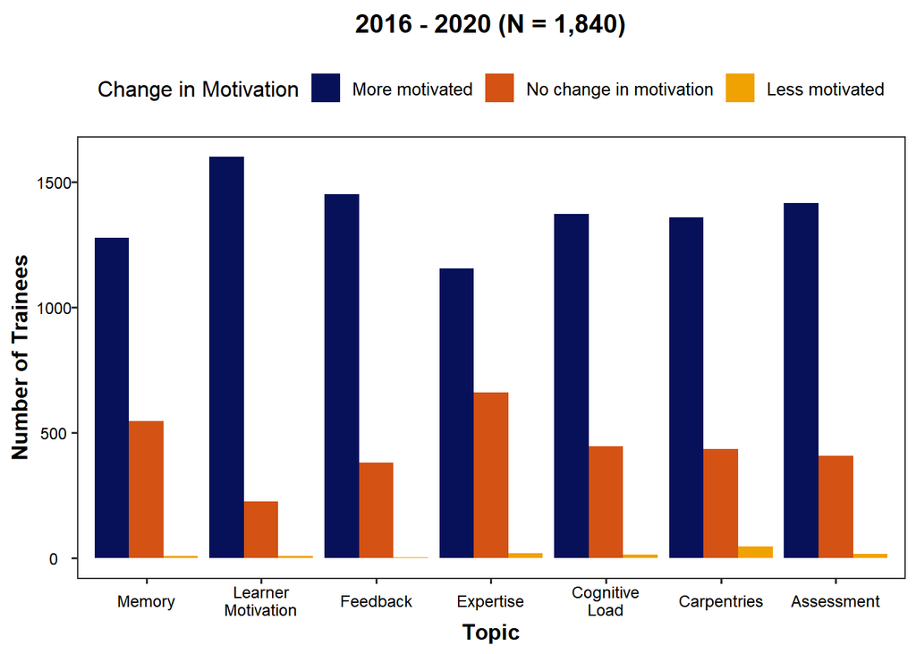

Figure 4.13: Change in Trainee Motivation to Learn More by Topic

## 4.5 How Was Instructor Training? Trainees’ Perceptions of the Instructor Training Experience.

After Instructor Training, trainees rated their level of agreement with the following statements on a 5-point Likert scale ranging from “Strongly Agree” to “Strongly Disagree”:

- The amount of information covered was reasonable for the allotted time.
- The overall atmosphere was welcoming.
- The material presented matched the description of the training event.
- This training was worth my time.

### 4.5.1 The amount of information covered was reasonable for the allotted time.

The majority of trainees (86%) either *agreed* or *strongly agreed* that the amount of information covered in Instructor Training was reasonable for the training time.

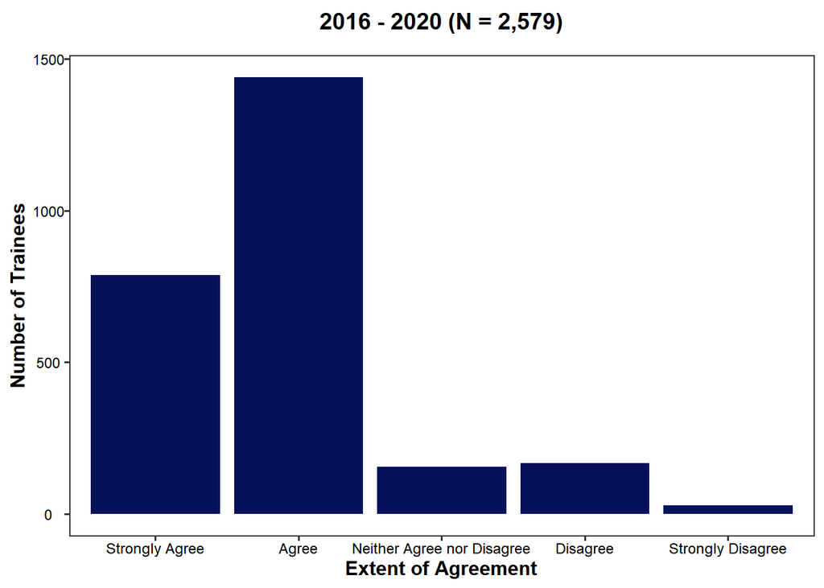

Figure 4.14: The amount of information covered was reasonable for allotted time

### 4.5.2 The overall atmosphere was welcoming.

The overwhelming majority of trainees (98%) either *agreed* or *strongly agreed* that the atmosphere during Instructor Training was welcoming.

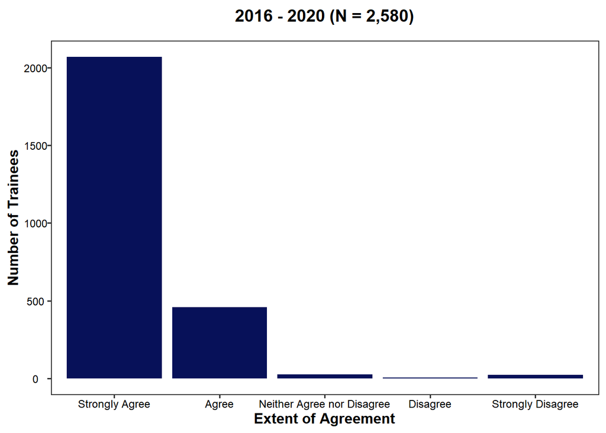

Figure 4.15: The overall atmosphere was welcoming

### 4.5.3 The material presented matched the description of the training event.

The majority of trainees (94%) either *agreed* or *strongly agreed* that the description of Instructor Training matched their experience.

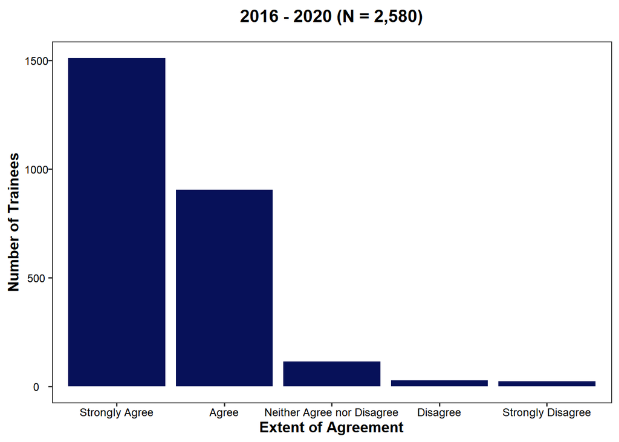

Figure 4.16: The material presented matched the description of the training event

### 4.5.4 This training was worth my time.

The majority of trainees (92%) either *agreed* or *strongly agreed* that Instructor training was worth their time.

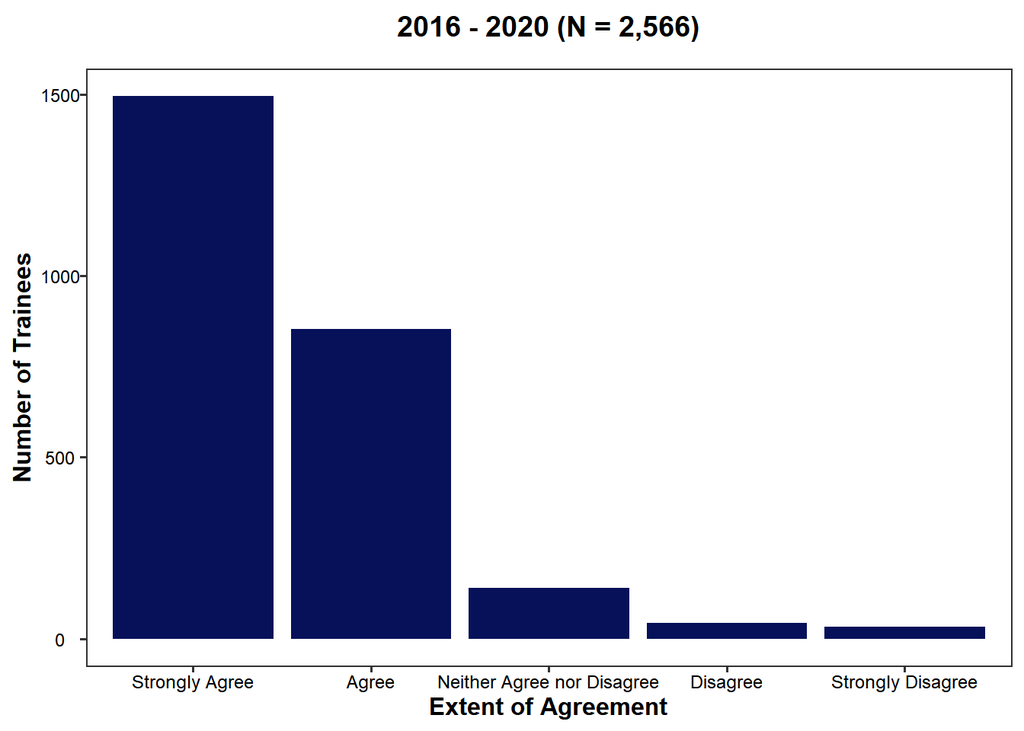

Figure 4.17: The training was worth my time

### 4.5.5 I would recommend this training to a friend or colleague.

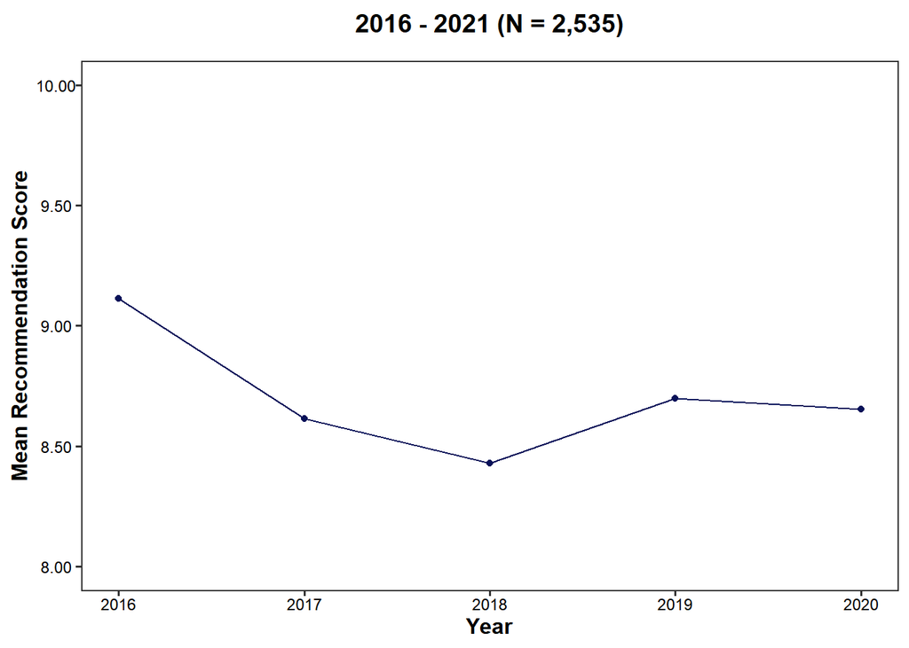

Figure 4.18: Likelihood of Recommendation by Year

### 4.5.6 Trainees Perceptions of the Pace of Instructor Training

Trainees indicated if they felt the pace of Instructor Training was *too fast*, *too slow*, or *just right*. The majority of trainees thought the speed was *just right* (56%). An additional 38% were split between thinking it was *slightly fast* or *slightly slow*.

These responses echo a common finding when asking about the pace of teaching. Most people will say the speed is just right, but invariably some trainees will think it was too fast or too slow. Because everyone has different experience levels and needs, the pace will not be perfect for everyone. However, we can try to make it just right for the majority.

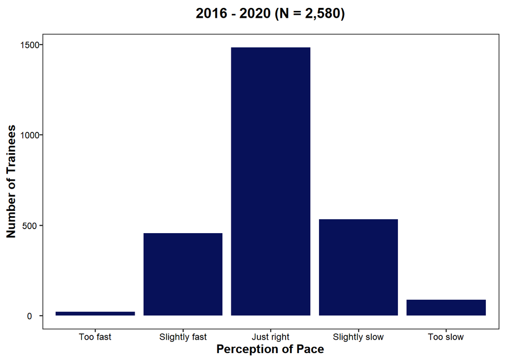

Figure 4.19: Instructor Trainees’ Perception of Pace

### 4.5.7 Trainees Perceptions of the Balance of Instructor Training

Trainees indicated how they felt about the balance between lecture and hands-on activities during Instructor Training. The majority of trainees (69%) thought the balance between lecture and hands-on work was good. If trainees thought that balance was off, they were more likely to think there was too much lecture (24%) rather than too much hands-on work (7%).

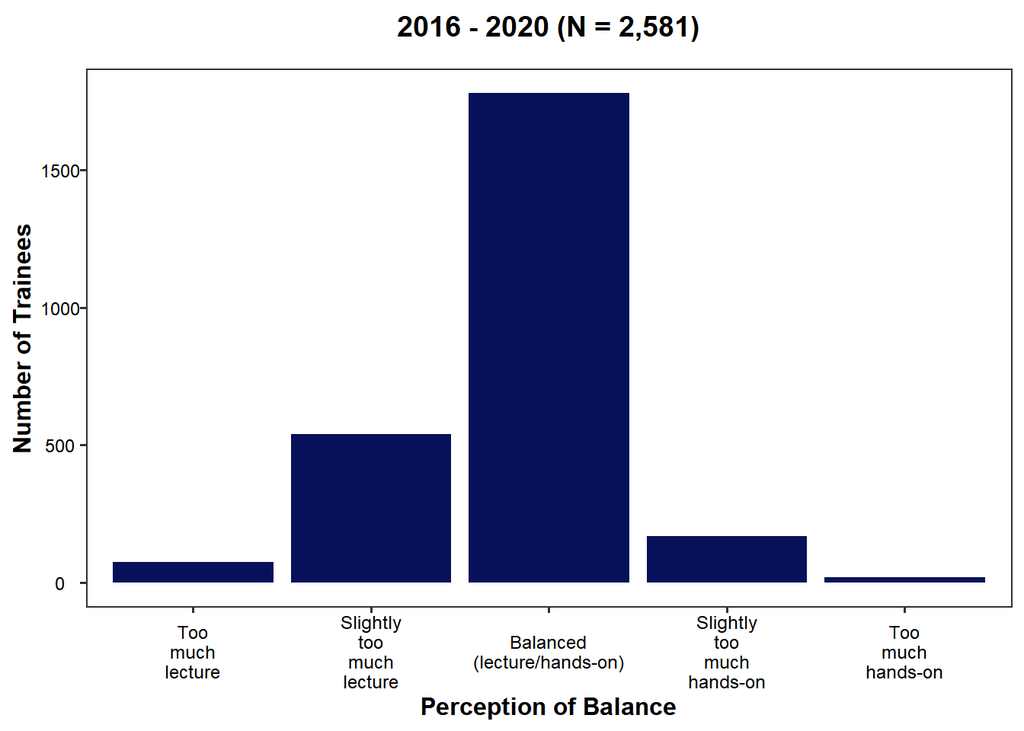

Figure 4.20: Instructor Trainees’ Perceptions of Balance

### 4.5.8 Summary of Trainees’ Perceptions of the Instructor Training Experience

Trainees reported positive perceptions of Instructor Training. They reported that it was welcoming, was taught at a comfortable pace, and had a good balance of lecture and hands on materials. Most trainees thought Instructor Training was worth their time and were very likely to recommend it to others. One potential area of improvement is the amount of information we cover in Instructor Training. While 86% of trainees either agreed or strongly agreed that the amount of material covered was reasonable, in contrast to other questions in this section, the majority (1,440 vs. 787) agreed rather than strongly agreeing. The idea that we may be trying to cover too much material is not new. We discuss this often in the Trainer community and have been working to address it in ongoing curriculum updates.

## 4.6 What Were Trainees’ Perceptions of Instructor Trainers?

After Instructor Training, trainees were asked to select how they felt the Instructor Trainer(s) performed based on the following statements:

- Instructor Trainer(s) gave clear answers to your questions.
- Instructor Trainer(s) were good communicators.
- Instructor Trainer(s) were considerate.
- Instructor Trainer(s) were enthusiastic.

### 4.6.1 Instructor Trainer(s) gave clear answers to your questions.

The majority of trainees (97%) thought Trainers gave clear answers to their questions *All of the time* or *Often*.

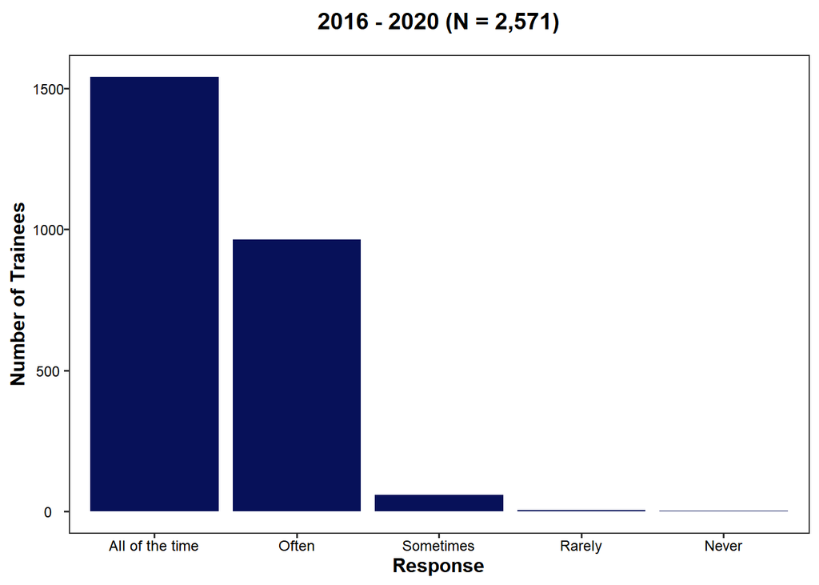

Figure 4.21: Instructor Trainers gave clear answers to your questions

### 4.6.2 Instructor Trainer(s) were good communicators.

The majority of trainees (97%) thought Trainers were good communicators *All of the time* or *Often*.

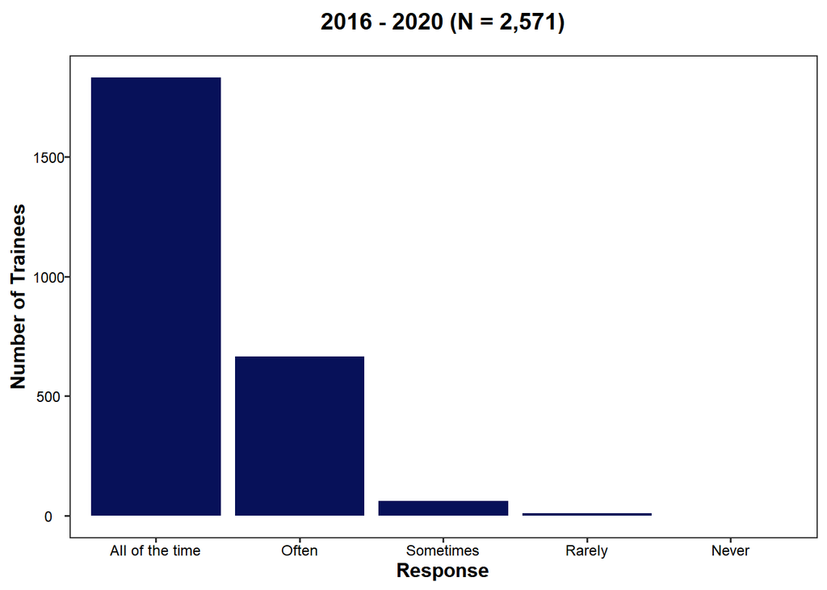

Figure 4.22: Instructor Trainers were good communicators

### 4.6.3 Instructor Trainer(s) were considerate.

The majority of trainees (99%) thought Trainers were considerate *All of the time* or *Often*.

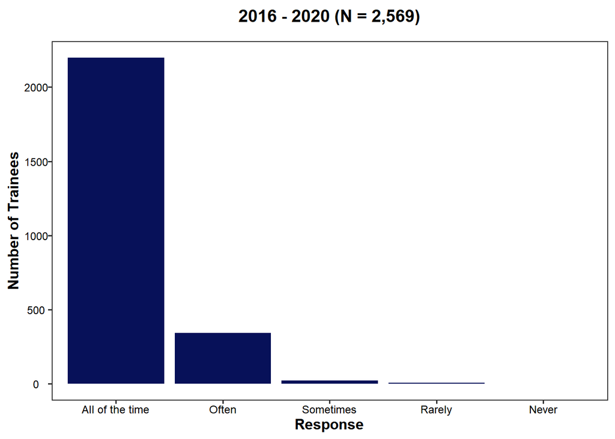

Figure 4.23: Instructor Trainers were considerate

### 4.6.4 Instructor Trainer(s) were enthusiastic.

The majority of trainees (98%) thought Trainers were enthusiastic *All of the time* or *Often*.

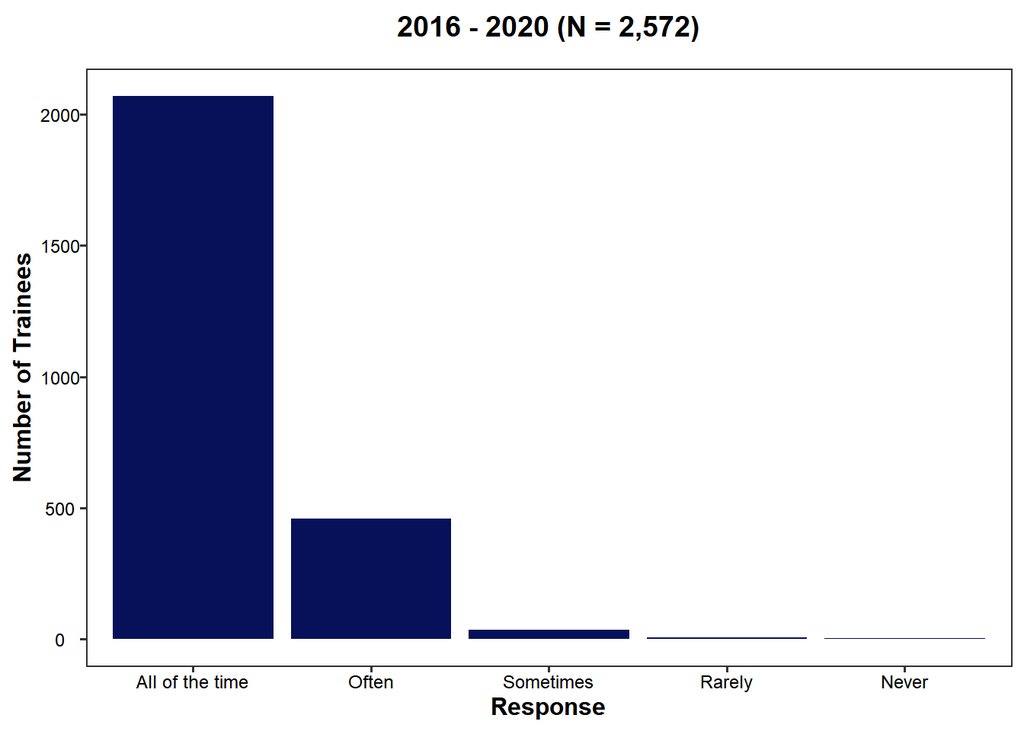

Figure 4.24: Instructor Trainers were enthusiastic

### 4.6.5 Summary of Trainees’ Perceptions of Instructor Trainers

We are fortunate to work with such outstanding Instructor Trainers. Our Trainers are rated highly across all categories. Trainees see them as good communicators who answer questions clearly, and are considerate and enthusiastic.

## 4.7 How did you find out about the Carpentries Instructor Training?

Before Instructor Training, we ask trainees how they found out about The Carpentries Instructor Training. The greatest number of trainees found out through a friend or colleague (55%) followed by an advisor or supervisor (26%). Smaller numbers of trainees learned about Instructor Training through Carpentries communications and social media.

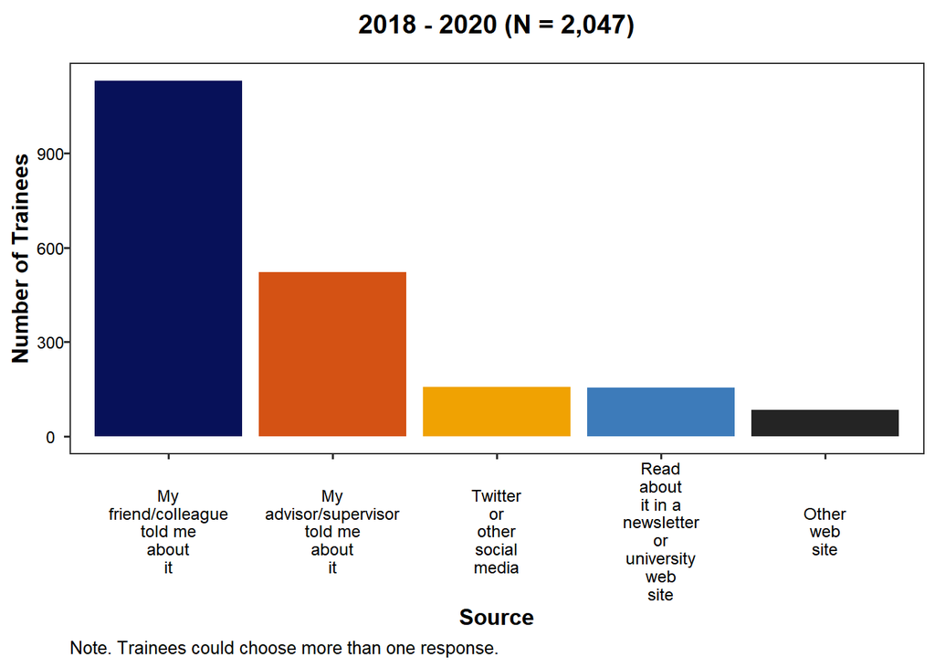

Figure 4.25: How Trainees Found Out About The Carpentries Instructor Training

## 4.8 Trainee Demographics

### 4.8.1 Country

Before Instructor Training, we ask trainees in what country their training takes place. A limitation of these data is that many trainings occur online, but it is unclear how someone taking the training online should answer this question. We assume that those online trainees answered with the country they were in at the time.

That limitation aside, this first graph shows the top ten countries trainees reported. Most trainees were in the United States, followed by the UK, Canada, and Australia. However, this list also has representation from European countries (e.g., Germany, Netherlands, Sweden) and South Africa, and Argentina.

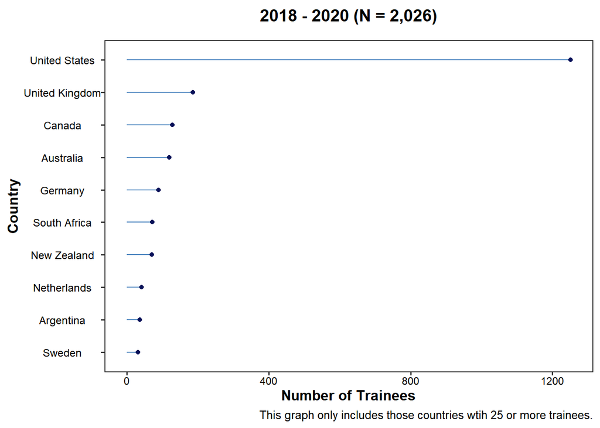

Figure 4.26: Top 10 Countries Trainees Come From

Below is a map showing all countries trainees have reported. The colors represent the number of trainees who reported that country from 2018 to 2020. Light grey indicates countries not reported.

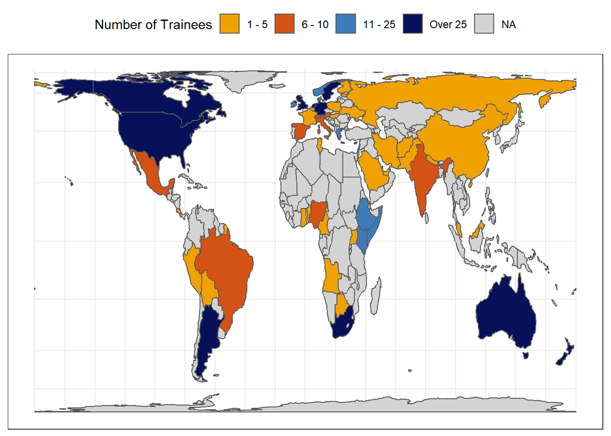

Figure 4.27: Instructor Trainees by Country

### 4.8.2 Instructor Trainees by Ethnic Identity

Trainees located in the United States were asked about their ethnic identity.

In the US from 2018 to 2020, the greatest number of trainees identify as white (66%), followed by Asian (17%) and Hispanic/Latino(a) (8%).

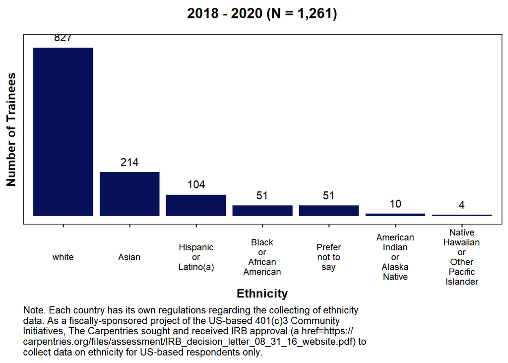

Figure 4.28: Instructor Trainees by Ethnic Identity

### 4.8.3 Instructor Trainees by Professional Profiles

The greatest percentage of trainees, as reported on the Instructor Training pre-surveys, come from the following domains: Computer Science (19%), Bioinformatics/Genomics (16%), and Library Science (12%). This distribution may reflect the origins of the Software, Data Carpentry, and Library Carpentry communities.

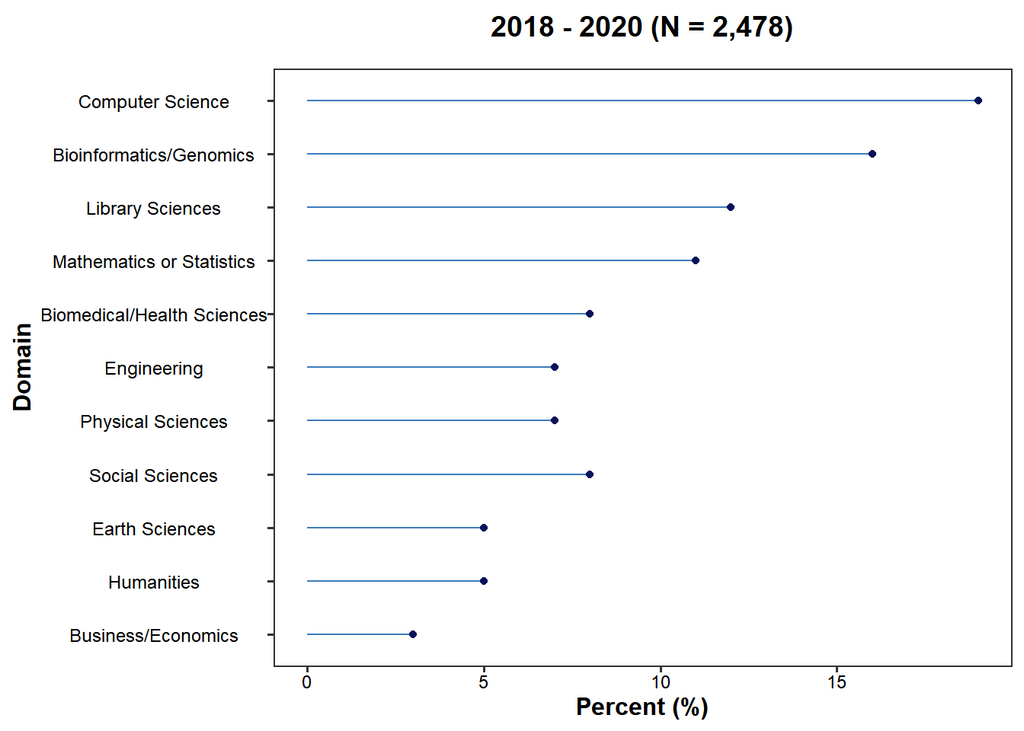

Figure 4.29: Instructor Trainees by Domain

The greatest percentage of our trainees are graduate students (26%) followed closely by research staff (24%). We also have a sizeable portion of faculty (16%) and postdoctoral researchers (13%). We have smaller numbers of trainees that come from government and industry.

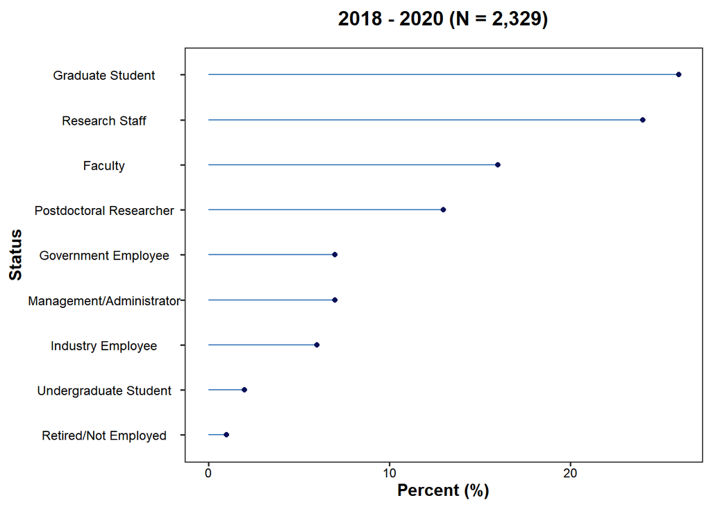

Figure 4.30: Instructor Trainees by Position

## 4.9 Why are you Attending The Carpentries Instructor Training?

According to our trainees, the most common reason for attending Instructor Training is to improve their general teaching skills followed closely by being able to teach Carpentries workshops.

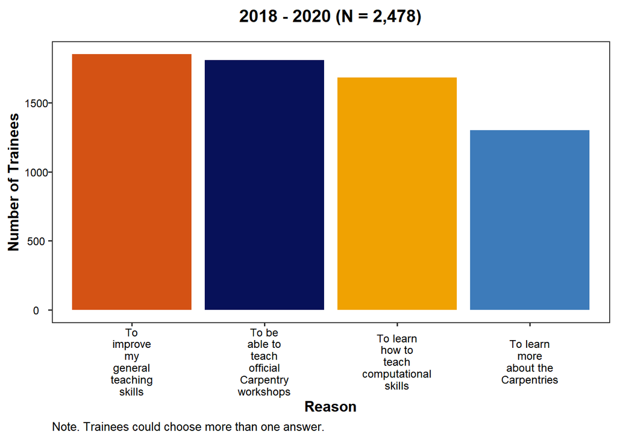

Figure 4.31: Instructor Trainee Motivation for Attending Instructor Training

# 5 Instructor Certification and Teaching: Outcomes, Challenges, and Opportunities

While one goal of The Carpentries Instructor Training Program is to develop the individual Instructor, another goal is related to building The Carpentries community. Each certified Carpentries Instructor becomes a member of a thriving community of practice.

## 5.1 Instructor Certification By Year

One goal of our Instructor Training program is to certify Instructors who will go on to teach Data Carpentry, Library Carpentry, and Software Carpentry workshops. However, a secondary goal is to share our pedagogical approach with those who want to improve their teaching skills. We are happy to train those who do not intend to certify and teach with The Carpentries. Therefore, not all individuals trained are expected to certify as Instructors. To become certified, one must complete a [three-step checkout process](https://carpentries.github.io/instructor-training/20-checkout/index.html) following training.

The Carpentries certified 630 instructors in 2019, the most in one year to date. This was a 10.9% increase from the year before. In 2020, we certified 494 instructors. This decrease reflects a reduction in the number of people trained in 2020, likely due to the pandemic.

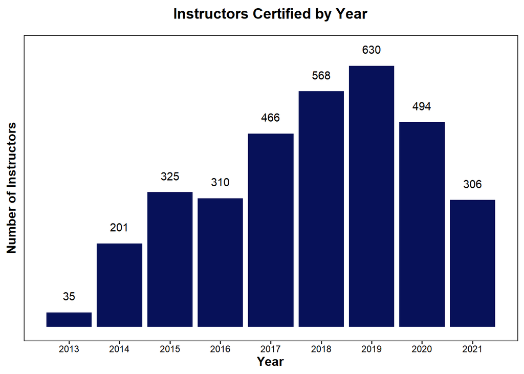

Figure 5.1: Instructors Certified by Year